# PTCAS Observation Hours

Karl Holub karl.holub@nested-knowledge.com

Molly Watkins mwatkins2@css.edu

# About

# Dataset

The dataset was sourced from the [PTCAS website](http://aptaapps.apta.org/ptcas/observationhours.aspx) (for requirements) & [Google Maps](https://google.com/maps) (for program locations). It has the following shape:

```r
dim(oh_data)
```

```
## [1] 243   7
```

meaning there are 243 programs & 7 (really 6) descriptive columns. Previewing it:

```r
head(oh_data, n=10)
```

|  | Instituition | Category | Minimum.Hours | Recommended.Hours | Latitude | Longitude | Requirement.Category |
| --- | --- | --- | --- | --- | --- | --- | --- |
| 1 | Adventist University of Health Sciences | 3 | NA | NA | 28.5763 | -81.3676 | PT hours are not required but are highly recommended |
| 2 | Alabama State University | 1 | 80 | NA | 32.3637 | -86.2941 | PT hours are required--a licensed PT must verify with signed form uploaded or online via PTCAS |
| 3 | Alvernia University | 1 | 100 | NA | 40.3112 | -75.9317 | PT hours are required--a licensed PT must verify with signed form uploaded or online via PTCAS |
| 4 | American International College | 1 | 20 | NA | 42.1129 | -72.5571 | PT hours are required--a licensed PT must verify with signed form uploaded or online via PTCAS |
| 5 | Angelo State University | 1 | 50 | NA | 31.4383 | -100.4603 | PT hours are required--a licensed PT must verify with signed form uploaded or online via PTCAS |
| 6 | Arcadia University | 2 | NA | NA | 40.0922 | -75.1656 | PT hours are required--no verification by a physical therapist |
| 7 | Arkansas State University | 4 | 0 | NA | 35.8431 | -90.6749 | PT hours are not required but are considered |
| 8 | Armstrong/Georgia Southern University | 1 | 75 | NA | 31.9784 | -81.1623 | PT hours are required--a licensed PT must verify with signed form uploaded or online via PTCAS |
| 9 | Army-Baylor University | 1 | 100 | NA | 31.5497 | -97.1143 | PT hours are required--a licensed PT must verify with signed form uploaded or online via PTCAS |
| 10 | AT Still University of Health Sciences | 2 | 30 | NA | 40.1936 | -92.5890 | PT hours are required--no verification by a physical therapist |

Outlining the non-trivial columns:

- Category: The type of the requirement the institution has for observation hours
- Minimum.Hours: The minimum number of observation hours required. May be missing if:
  - The program doesn’t require hours
  - The program doesn’t publish an explicit number, in favor of “case by case” consideration. Students should still expect to need to have some hours for acceptance.
- Recommended.Hours: Optional and potentially different from minimum hours
  - Some programs supply a range (e.g. “400-600”“) or lower bounded range (e.g.”100+“”). For this analysis, only the lower bound is used.
- Latitude & Longitude: Approximate (hand selected on map) location of the center of the institution’s campus

# Summary Statistics

## Requirement Category

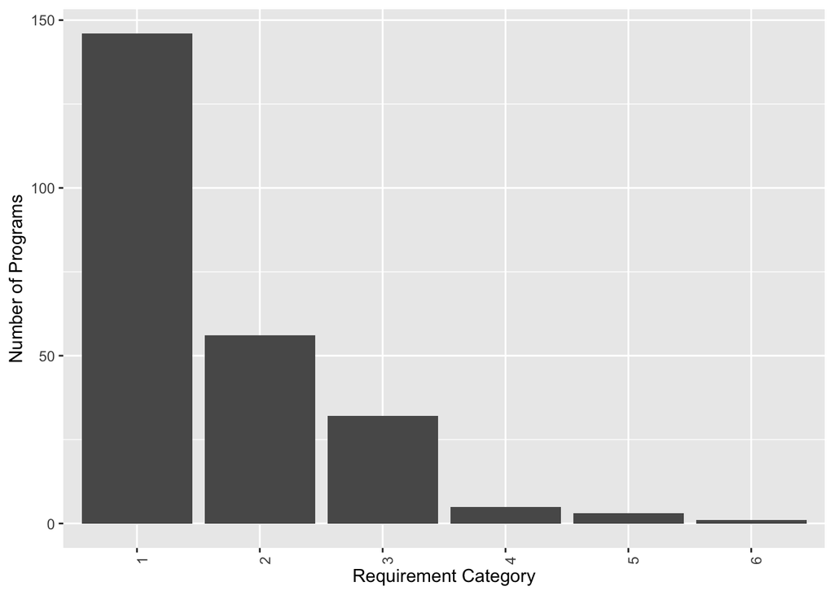

```r
oh_data %>%
  ggplot() +
    geom_bar(aes(as.factor(Category))) +
    theme(axis.text.x = element_text(angle = 90, hjust = 1)) +
    xlab('Requirement Category') +
    ylab('Number of Programs')
```

where the categories are:

```r
categories
```

| id | Requirement.Category |
| --- | --- |
| 1 | PT hours are required--a licensed PT must verify with signed form uploaded or online via PTCAS |
| 2 | PT hours are required--no verification by a physical therapist |
| 3 | PT hours are not required but are highly recommended |
| 4 | PT hours are not required but are considered |
| 5 | PT hours are not required or considered |
| 6 | Other |

83% of programs require observation hours.

## Required Hours

```r
summary(oh_data$Minimum.Hours)
```

```
##    Min. 1st Qu.  Median    Mean 3rd Qu.    Max.    NA's
##    0.00   40.00   50.00   55.43   80.00  300.00      31
```

The distribution of hours across all programs looks like:

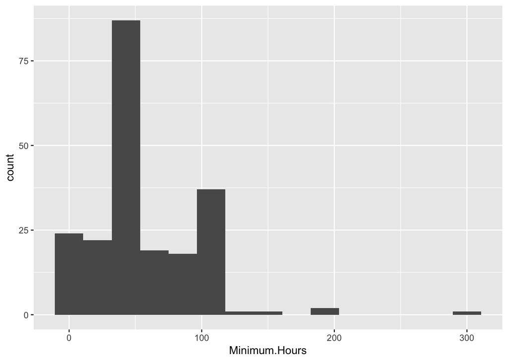

```r
oh_data %>%
  filter(!is.na(Minimum.Hours)) %>%
  ggplot() +
    geom_histogram(aes(Minimum.Hours), bins = 15)
```

Peeking at distributions conditioned on the requirement category (specifically 1 & 2, which do impose a requirement):

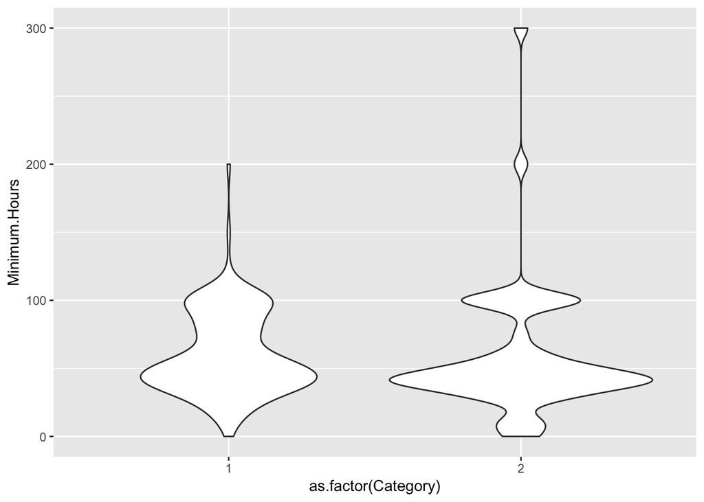

```r
oh_data %>%
  filter(!is.na(Minimum.Hours) & Category %in% c(1,2)) %>%
  ggplot() +
    geom_violin(aes(as.factor(Category), Minimum.Hours))
```

The distributions are similar, with modes at 40 & 100 hours.

# Incorporating Geography

## Visualizing

### Points

First, we view each program as a point on the US map, where color indicates the hours requirement:

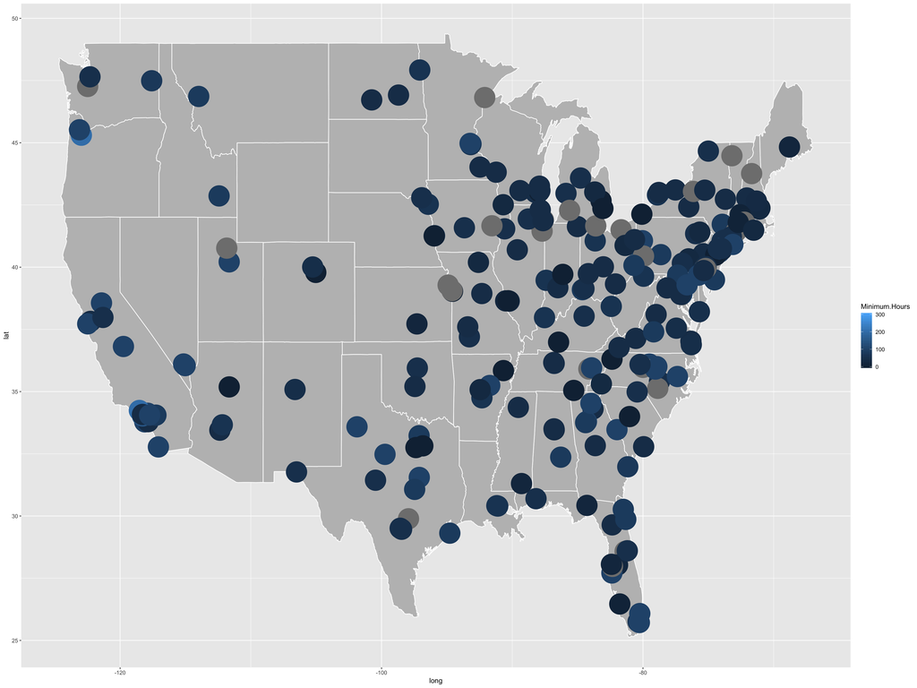

```r
us <- map_data('state')

gg <- oh_data %>%
  ggplot()  +
    geom_polygon(data = us, aes(x=long, y = lat, group = group), fill='grey', color='white') +
  geom_point(aes(x=Longitude, y=Latitude, color = Minimum.Hours), size=15)

gg
```

There is heavy concentration of programs in the Northeast US, so we zoom in:

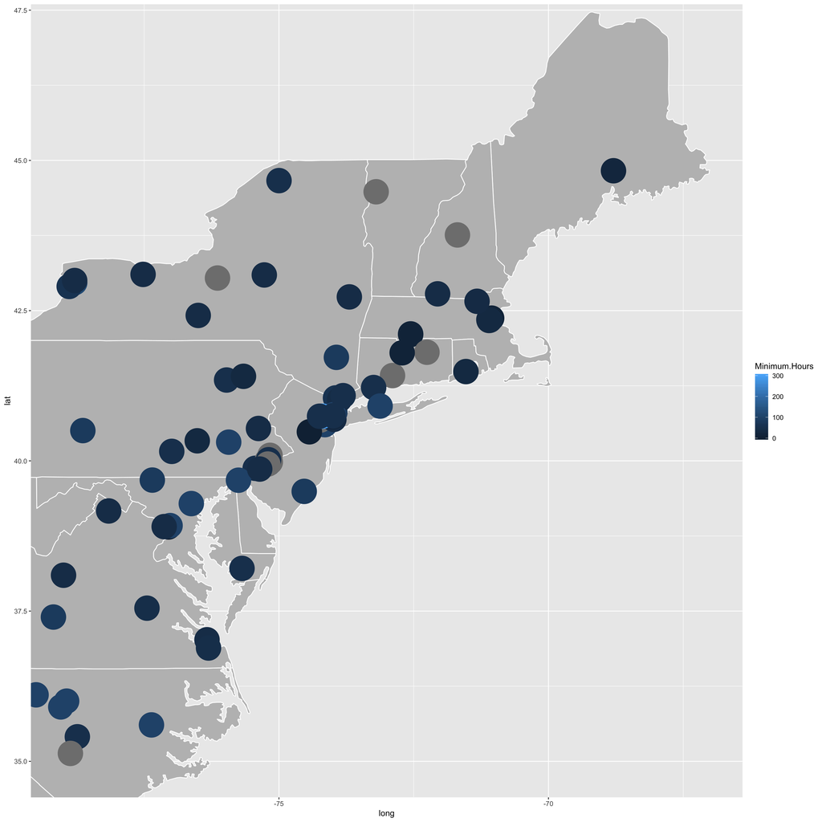

```r
gg + coord_cartesian(xlim = c(-79, -67), ylim = c(35, 47))
```

### Heatmap

TODO: This isn’t very pretty or effective, despite probably being the most important graph!

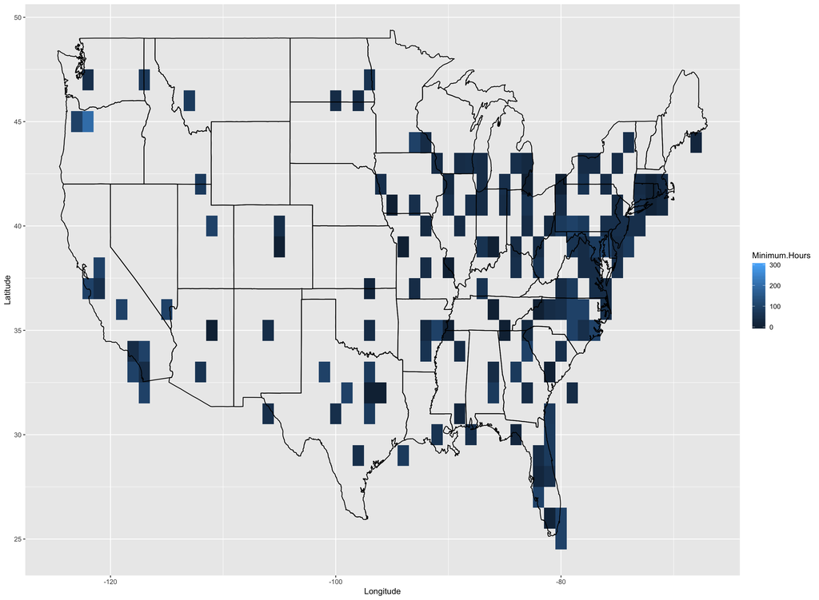

```r
oh_data %>%
  filter(!is.na(Minimum.Hours)) %>%
  mutate(
    Latitude = as.integer(Latitude),
    Longitude = as.integer(Longitude)
  ) %>%
ggplot() +
  geom_tile(aes(x = Longitude, y = Latitude, fill = Minimum.Hours)) +
  geom_polygon(data = us, aes(x=long, y = lat, group = group), alpha=0, color='black')
```

There certainly appears to be a trend of decreasing hour trends as Longitude increases (moving towards the East). There also appears to be pockets of high requirements in the “central” east, which might suggest a network analysis, or ranged interaction effects in latitude and longitude.

## Correlations

### Main Effect Lat/Long

#### Visualizing

To visualize main effect correlations, we look at marginal x/y plots of latitude and longitude. Smoothing splines are used to trend the data.

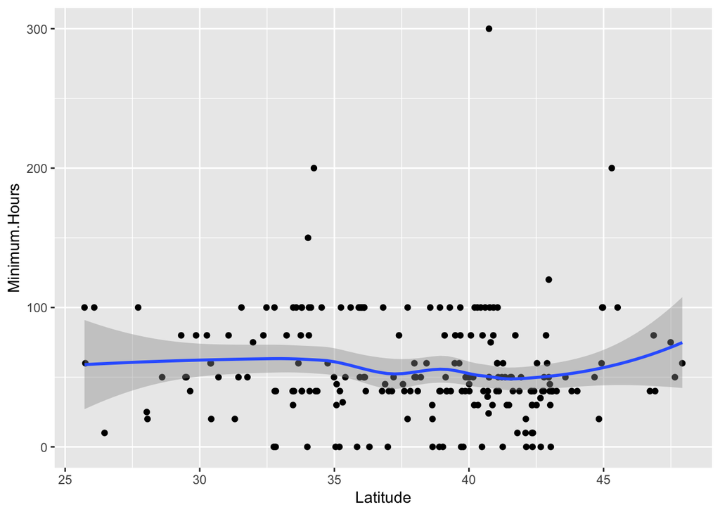

```r
oh_data %>%
  filter(!is.na(Minimum.Hours)) %>%
  ggplot(aes(Latitude, Minimum.Hours)) +
    geom_point() +
    geom_smooth()
```

Hours look pretty flat across Latitude, with perhaps a slight decrease moving North.

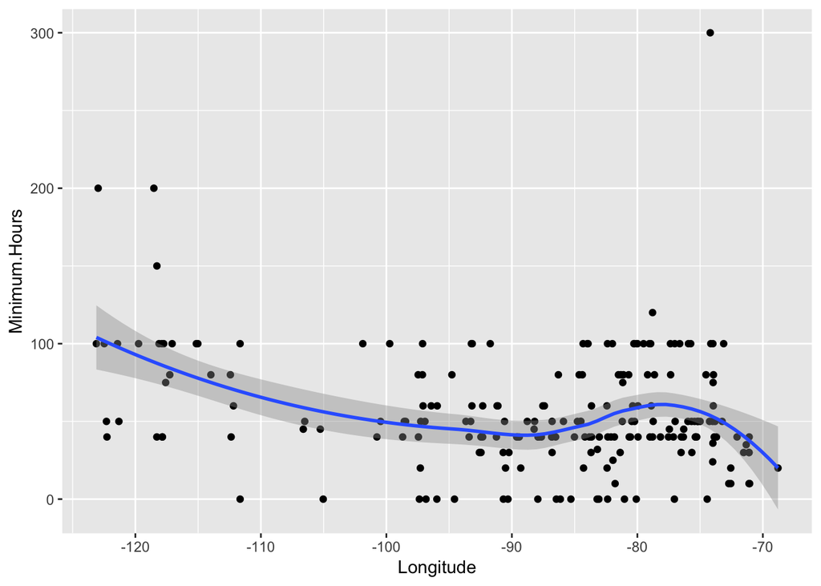

```r
oh_data %>%
  filter(!is.na(Minimum.Hours)) %>%
  ggplot(aes(Longitude, Minimum.Hours)) +
    geom_point() +
    geom_smooth()
```

#### Inference (Non-zero Effects)

To determine if the main effect correlations are non-zero, we perform a bootstrap on the correlation coefficients, building 95% intervals:

```r
bs <- bootstrap(oh_data %>% filter(!is.na(Minimum.Hours)), corr_lat = cor(Latitude, Minimum.Hours, method='spearman'), corr_long = cor(Longitude, Minimum.Hours, method='spearman'))

summary.bootstrap(bs)
```

```
## Number of boostrap samples: 100
## Empirical interval level: 0.95
##
##  statistic       mean standard_error   ci_lower    ci_upper
##   corr_lat -0.1388511     0.07215368 -0.2713761 -0.01450145
##  corr_long -0.1552041     0.06925143 -0.2810271 -0.02757254
```